# 6. Repeated Measures ANOVA (RMA)

## 6.2.b Paarsgewijze vergelijking met Bonferroni

**TipHoeveel paren bij $k$ niveaus?**

Bij $k$ momenten zijn er $\binom{k}{2} = \dfrac{k(k-1)}{2}$ paarsgewijze vergelijkingen:

| $k$ | $\binom{k}{2}$ | Bonferroni-drempel ($\alpha = .05$) |
| --- | --- | --- |
| 2 | 1 | $.050$ |
| 3 | 3 | $.0167$ |
| 4 | **6** | $.0083$ |
| 5 | 10 | $.0050$ |
| 6 | 15 | $.0033$ |

Voor onze kameleon met vier momenten zijn dat **zes** paren: $(O,M), (O,A), (O,N), (M,A), (M,N), (A,N)$. Bonferroni-corrected $\alpha_{\text{per paar}} = .05 / 6 \approx .008$.

**Algemene vorm — Leiden’s `emmeans_test()`-route.**

`emmeans_test()` (uit `rstatix`) levert pairwise EMM-vergelijkingen met Bonferroni in één call. Maar onder de motorkap fit `emmeans()` het model — en voor RMA-pairwise heeft `emmeans()` een model nodig waarin **moment als variabele in de modelformule staat** met een **Error-term per persoon**. Dat is precies wat `aov(y ~ moment + Error(id/moment))` levert. (Het `mlm`-object uit `factorial_design()` werkt hier niet — daar zit `moment` impliciet in de kolomvolgorde.)

We bouwen daarom **twee modellen parallel**: `factorial_design()` voor de multivariate-en-univariate RMA-output (sectie 6.1.b), en `aov()` met Error-term voor de pairwise vergelijkingen hier:

```r
# Pairwise EMM-vergelijkingen met Bonferroni — model = aov(. + Error(id/within))
library(rstatix)
m_aov <- aov(score ~ moment + Error(id/moment), data = long_data)
em_pairs <- long_data |>
  emmeans_test(
    score ~ moment,
    p.adjust.method = "bonferroni",
    model           = m_aov
  )
em_pairs
```

Output: één rij per paar met `estimate`, `SE`, `df`, `statistic` ($t$-ratio), `p.adj`. De `df` is hier de **gepoolde within-error-df** ($(n-1)(k-1)$), niet de paarsgewijze paired-$t$-df ($n-1$) — RMA gebruikt de gepoolde error-schatting voor meer statistische power.

**Voor onze dieren.**

```r
# Tweede model: aov() met Error(id/moment) — voorwaarde voor emmeans_test().
m_kam_aov <- aov(mate_van_zichzelf ~ moment + Error(id/moment),
                 data = kameleon_long)

em_pairs_kam <- kameleon_long |>
  emmeans_test(
    mate_van_zichzelf ~ moment,
    p.adjust.method = "bonferroni",
    model           = m_kam_aov
  )

em_pairs_kam |>
  select(group1, group2, df, statistic, p, p.adj, p.adj.signif) |>
  print()
```

```
# A tibble: 6 × 7
  group1  group2    df statistic        p    p.adj p.adj.signif
  <chr>   <chr>  <dbl>     <dbl>    <dbl>    <dbl> <chr>
1 ochtend middag   267     16.1  4.08e-41 2.45e-40 ****
2 ochtend avond    267      8.10 1.93e-14 1.16e-13 ****
3 ochtend nacht    267     -8.02 3.39e-14 2.03e-13 ****
4 middag  avond    267     -7.97 4.74e-14 2.84e-13 ****
5 middag  nacht    267    -24.1  6.61e-69 3.97e-68 ****
6 avond   nacht    267    -16.1  2.68e-41 1.61e-40 ****
```

**NoteTwee modellen, één design — waarom?**

`factorial_design()` is gebouwd om de **RMA-output** te produceren: multivariate Pillai/Wilks-tabellen, univariate Type-III met sphericity-correctie. Daarvoor schrijft het achter de schermen een `lm(cbind(t1, t2, t3, t4) ~ 1)` (een **mlm**, multivariate lineair model) — moment zit impliciet in de kolomvolgorde van de DV-matrix.

`emmeans()` daarentegen wil moment als **variabele in de modelformule** zien, niet als kolom-index. Daarom bouw je voor de pairwise stap een tweede model met `aov(. + Error(id/moment))` op de long-vorm. Beide modellen schatten dezelfde gepoolde within-error; de Type-III-Sum-of-Squares (sectie 6.1.b) en de pairwise contrasts (hier) komen overeen.

Geen dubbel werk in de analyse-stap — wel twee modellen in de R-code, omdat de twee output-vormen elk hun eigen model-structuur nodig hebben. Op het tentamen kan je naar de syntax van **beide** worden gevraagd.

**TipKlassieke paired-$t$-route — alternatief**

Voor wie geen `emmeans_test()` wil gebruiken: dezelfde zes paren via gewone `t.test()`-aanroepen plus handmatige Bonferroni-correctie:

```r
ps <- c(
  o_m = t.test(kameleon_momenten$ochtend, kameleon_momenten$middag, paired = TRUE)$p.value,
  o_a = t.test(kameleon_momenten$ochtend, kameleon_momenten$avond,  paired = TRUE)$p.value,
  o_n = t.test(kameleon_momenten$ochtend, kameleon_momenten$nacht,  paired = TRUE)$p.value,
  m_a = t.test(kameleon_momenten$middag,  kameleon_momenten$avond,  paired = TRUE)$p.value,
  m_n = t.test(kameleon_momenten$middag,  kameleon_momenten$nacht,  paired = TRUE)$p.value,
  a_n = t.test(kameleon_momenten$avond,   kameleon_momenten$nacht,  paired = TRUE)$p.value
)
round(p.adjust(ps, method = "bonferroni"), 4)
```

Wiskundig gelijk; alleen niet wat Leiden’s R-practical voorschrijft.

**NoteVragen 6.2**

**e)** Hoeveel paren toets je bij $k = 4$ momenten? Wat is $\alpha_{\text{per paar}}$ na Bonferroni?

**f)** Welke paren zijn significant na Bonferroni-correctie?

**g)** Welk paar heeft de grootste $t$-waarde? Wat zegt dat?

**CautionAntwoord — open na je eigen poging**

**In gewone woorden.**

**APA-stijl.**

## T6 — Bonferroni voor RMA-paren handrekenen

**NoteVraag T6 — Pen-en-papier**

Bij $k = 5$ momenten doe je paarsgewijze vergelijkingen met Bonferroni-correctie.

**a)** Hoeveel paren zijn er?

**b)** Wat is $\alpha_{\text{per paar}}$?

**c)** Een paar heeft $p = .009$. Significant na Bonferroni?

**d)** Een paar heeft $p = .003$. Significant na Bonferroni?

**CautionAntwoord — open na je eigen poging**

**a)** $\binom{5}{2} = 5 \cdot 4 / 2 = 10$ paren.

**b)** $\alpha_{\text{per paar}} = .05 / 10 = .005$.

**c)** $p = .009 > .005$ — niet significant na Bonferroni. (Wel significant op de gewone $.05$.)

**d)** $p = .003 < .005$ — wel significant na Bonferroni.

**Inzicht.** Bonferroni voor RMA-paren: hetzelfde mechanisme als bij MANOVA in thema 5, alleen tellen we nu paren-binnen-een-factor in plaats van DV’s. Bij veel momenten wordt de drempel snel streng — overweeg dan polynomiale contrasten als alternatief.

## 6.2.c Visualisatie — gemiddeld profiel + spaghetti

**Toon code (interaction-plot stijl: groepsgemiddelde + 95% CI + spaghetti)**

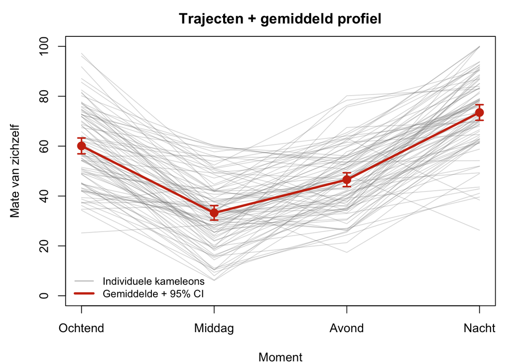

```r
means_v <- colMeans(kameleon_momenten[, c("ochtend", "middag", "avond", "nacht")])
sds_v   <- apply(kameleon_momenten[, c("ochtend", "middag", "avond", "nacht")], 2, sd)
n_k     <- nrow(kameleon_momenten)
ses_v   <- sds_v / sqrt(n_k)
ci_lo   <- means_v - 1.96 * ses_v
ci_hi   <- means_v + 1.96 * ses_v

matY <- as.matrix(kameleon_momenten[, c("ochtend", "middag", "avond", "nacht")])

par(mar = c(4, 4.5, 2.5, 1))
matplot(t(matY), type = "l", lty = 1,
        col = adjustcolor("#888888", alpha.f = 0.30),
        xaxt = "n", xlab = "Moment", ylab = "Mate van zichzelf",
        ylim = c(0, 100),
        main = "Trajecten + gemiddeld profiel")
axis(1, at = 1:4, labels = c("Ochtend", "Middag", "Avond", "Nacht"))

# Gemiddeld profiel met error bars.
arrows(1:4, ci_lo, 1:4, ci_hi, length = 0.05, angle = 90, code = 3,
       col = "#CC3311", lwd = 2)
lines(1:4, means_v, col = "#CC3311", lwd = 3)
points(1:4, means_v, col = "#CC3311", pch = 16, cex = 1.6)

legend("bottomleft",
       legend = c("Individuele kameleons", "Gemiddelde + 95% CI"),
       col    = c(adjustcolor("#888888", alpha.f = 0.7), "#CC3311"),
       lty    = 1,
       lwd    = c(1, 3),
       bty    = "n",
       cex    = 0.85)
```

# 6.3 Polynomial-trends-surprise — vier dagdeel-profielen

*Eerst raden, dan rekenen — wat zegt het oog, wat zegt de optelling?*

> *“Vier kameleons, ieder met een eigen dagritme,” vertelde de oude kameleon. “Sommigen volgen een rechte lijn. Sommigen zakken in het midden in. Sommigen springen op en neer. En een paar lijken iets te doen wat niet helemaal is wat het lijkt.”*

In deze opgave krijg je vier dagdeel-profielen, één per fictieve kameleon. Per profiel: het gemiddelde mate-van-zichzelf op de vier momenten ochtend / middag / avond / nacht. **Voor je gaat rekenen**, kijk eerst goed naar elk profiel en gok welke polynomiale trend dominant is: lineair, kwadratisch, kubisch, of geen.

Daarna reken je voor elk profiel de drie contrasten uit en kijk je of je intuïtie klopt. Bij minstens één profiel zit een verrassing.

**TipWat ga je rekenen?**

Drie polynomiale contrasten op vier geordende niveaus, met de **niet-genormaliseerde** gewichten (handrekenbaar):

- **Lineair** $L_1$: gewichten $(-3, -1, +1, +3)$ — meet stijging of daling
- **Kwadratisch** $L_2$: gewichten $(+1, -1, -1, +1)$ — meet U-vorm of omgekeerde U
- **Kubisch** $L_3$: gewichten $(-1, +3, -3, +1)$ — meet S-vorm (op-neer-op of neer-op-neer)

Per profiel: $L_k = \sum_j c_{kj} \cdot \bar{Y}_j$. Rangschik op absolute waarde — de grootste $|L_k|$ is de dominante trend.

## De vier profielen

**Toon code (gt-tabel met vier profielen)**

```r
profielen <- data.frame(
  Kameleon = c("Anita",        "Berend",     "Clara",       "Dirk"),
  ochtend  = c( 5,              0,             9,             3),
  middag   = c( 5,              3,             7,             7),
  avond    = c( 5,              4,             4,             5),
  nacht    = c( 5,              1,             0,             9)
)

profielen |>
  gt() |>
  tab_header(title = "Vier kameleon-profielen — gemiddelde mate-van-zichzelf per moment") |>
  cols_label(Kameleon = "Kameleon",
             ochtend  = "Ochtend",
             middag   = "Middag",
             avond    = "Avond",
             nacht    = "Nacht") |>
  tab_options(table.font.size = px(13),
              table.border.top.style    = "none",
              table.border.bottom.style = "none")
```

Vier kameleon-profielen — gemiddelde mate-van-zichzelf per moment

| Kameleon | Ochtend | Middag | Avond | Nacht |
| --- | --- | --- | --- | --- |
| Anita | 5 | 5 | 5 | 5 |
| Berend | 0 | 3 | 4 | 1 |
| Clara | 9 | 7 | 4 | 0 |
| Dirk | 3 | 7 | 5 | 9 |

## Visualisatie — vier profielen in één plot

**Toon code (lineplot vier profielen)**

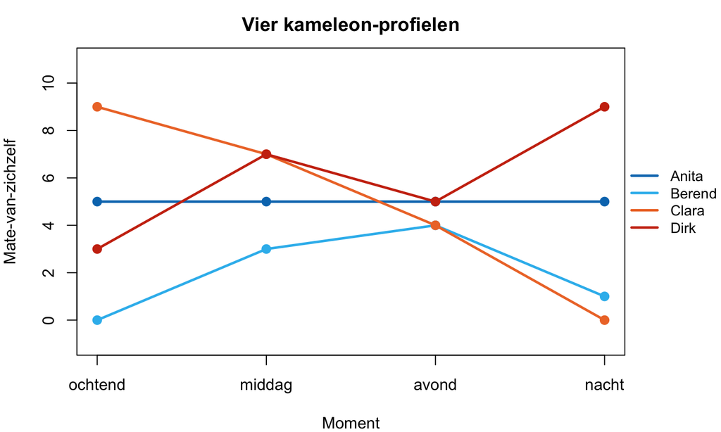

```r
profielen_long <- data.frame(
  Kameleon = rep(profielen$Kameleon, each = 4),
  moment   = factor(rep(c("ochtend", "middag", "avond", "nacht"), times = 4),
                    levels = c("ochtend", "middag", "avond", "nacht")),
  waarde   = c(t(profielen[, 2:5]))
)

par(mar = c(4, 4, 2.5, 5), xpd = TRUE)
plot(NA, xlim = c(1, 4), ylim = c(-1, 11),
     xaxt = "n", xlab = "Moment", ylab = "Mate-van-zichzelf",
     main = "Vier kameleon-profielen")
axis(1, at = 1:4, labels = c("ochtend", "middag", "avond", "nacht"))

kleuren <- c(Anita = "#0077BB", Berend = "#33BBEE", Clara = "#EE7733", Dirk = "#CC3311")

for (k in profielen$Kameleon) {
  waardes <- as.numeric(profielen[profielen$Kameleon == k, 2:5])
  lines(1:4, waardes, col = kleuren[k], lwd = 2.5)
  points(1:4, waardes, col = kleuren[k], pch = 19, cex = 1.2)
}

legend("right", inset = c(-0.18, 0), legend = names(kleuren),
       col = kleuren, lwd = 2.5, bty = "n", cex = 0.9)
```

**NoteVraag 6.3.a — Eerst kijken en raden (pen-en-papier, geen rekenen)**

Voor elk van de vier kameleons: welke polynomiale trend lijkt visueel dominant?

- **Anita**: _________________________
- **Berend**: _________________________
- **Clara**: _________________________
- **Dirk**: _________________________

Geef per kameleon je beste gok: lineair, kwadratisch, kubisch, of geen trend. Schrijf ook kort op *waarom* je dat ziet.

## 6.3.a Reken de drie contrasten uit

```r
L1 <- c(-3, -1,  1,  3)  # lineair
L2 <- c( 1, -1, -1,  1)  # kwadratisch
L3 <- c(-1,  3, -3,  1)  # kubisch

bereken_contrasten <- function(profile) {
  c(L1 = sum(L1 * profile),
    L2 = sum(L2 * profile),
    L3 = sum(L3 * profile))
}

resultaten <- t(apply(profielen[, 2:5], 1, bereken_contrasten))
rownames(resultaten) <- profielen$Kameleon

cat("Contrast-waardes per kameleon:\n")
```

```
Contrast-waardes per kameleon:
```

```r
print(resultaten)
```

```
        L1 L2 L3
Anita    0  0  0
Berend   4 -6 -2
Clara  -30 -2  0
Dirk    16  0 12
```

```r
cat("\nAbsolute waardes (sterkste eerst per rij):\n")
```

```
Absolute waardes (sterkste eerst per rij):
```

```r
rangorde <- t(apply(abs(resultaten), 1, function(x) names(x)[order(-x)]))
rownames(rangorde) <- profielen$Kameleon
print(rangorde)
```

```
       [,1] [,2] [,3]
Anita  "L1" "L2" "L3"
Berend "L2" "L1" "L3"
Clara  "L1" "L2" "L3"
Dirk   "L1" "L3" "L2"
```

**NoteVragen 6.3.b — Rekenen en rangschikken**

**a)** Wat zijn de drie contrast-waardes voor **Berend** $(0, 3, 4, 1)$? Welke trend is dominant?

**b)** Wat zijn de drie contrast-waardes voor **Clara** $(9, 7, 4, 0)$? Welke trend is dominant?

**c)** Wat zijn de drie contrast-waardes voor **Dirk** $(3, 7, 5, 9)$? Welke trend is dominant? **Komt dit overeen met je gok in vraag 6.3.a?**

**d)** Wat zijn de drie contrast-waardes voor **Anita** $(5, 5, 5, 5)$? Wat zegt dat?

**e)** Rangschik per kameleon op absolute waarde. Welke trend domineert, welke is tweede, welke derde?

**CautionAntwoord — open na je eigen poging**

**Anita** $(5, 5, 5, 5)$:

- $L_1 = -3(5) - 1(5) + 1(5) + 3(5) = -15 - 5 + 5 + 15 = 0$
- $L_2 = 1(5) - 1(5) - 1(5) + 1(5) = 5 - 5 - 5 + 5 = 0$
- $L_3 = -1(5) + 3(5) - 3(5) + 1(5) = -5 + 15 - 15 + 5 = 0$

Alle drie nul — er is **geen trend**. Constante waarde laat geen polynomial-trend zien. Anita is een rust-kameleon.

**Berend** $(0, 3, 4, 1)$:

- $L_1 = -3(0) - 1(3) + 1(4) + 3(1) = 0 - 3 + 4 + 3 = 4$
- $L_2 = 1(0) - 1(3) - 1(4) + 1(1) = 0 - 3 - 4 + 1 = -6$
- $L_3 = -1(0) + 3(3) - 3(4) + 1(1) = 0 + 9 - 12 + 1 = -2$

Absoluut: $|L_2| = 6 > |L_1| = 4 > |L_3| = 2$. **Kwadratisch dominant** — Berend heeft een piek in het midden (middag-avond hoog, ochtend en nacht laag). Negatief kwadratisch contrast = omgekeerde U-vorm.

**Clara** $(9, 7, 4, 0)$:

- $L_1 = -3(9) - 1(7) + 1(4) + 3(0) = -27 - 7 + 4 + 0 = -30$
- $L_2 = 1(9) - 1(7) - 1(4) + 1(0) = 9 - 7 - 4 + 0 = -2$
- $L_3 = -1(9) + 3(7) - 3(4) + 1(0) = -9 + 21 - 12 + 0 = 0$

Absoluut: $|L_1| = 30 \gg |L_2| = 2 > |L_3| = 0$. **Lineair dominant**, sterk negatief — Clara daalt monotoon over de dag.

**Dirk** $(3, 7, 5, 9)$:

- $L_1 = -3(3) - 1(7) + 1(5) + 3(9) = -9 - 7 + 5 + 27 = 16$
- $L_2 = 1(3) - 1(7) - 1(5) + 1(9) = 3 - 7 - 5 + 9 = 0$
- $L_3 = -1(3) + 3(7) - 3(5) + 1(9) = -3 + 21 - 15 + 9 = 12$

Absoluut: $|L_1| = 16 > |L_3| = 12 \gg |L_2| = 0$. **Lineair dominant**, daarna kubisch — Dirk stijgt over de hele dag, met een S-vormige rimpel erin.

**Surprise — vraag e) over Dirk**. Visueel ziet Dirks profiel er wisselend uit: hij gaat omhoog (3 → 7), zakt in (7 → 5), schiet weer omhoog (5 → 9). Het *oog* leest dat als kubisch-dominante S-vorm. Maar de **rekenkundige sterkste trend is lineair** — over de hele dag stijgt hij. De kubische component is er wel, maar minder sterk dan de lineaire.

**Inzicht**: het oog ziet bewegingen op de *korte termijn* (op-neer-op), het rekenen registreert de *grote lijn* (begin laag, eind hoog). Allebei waar, allebei in de drie contrasten verdeeld. **Rapporteer in volgorde van absolute sterkte**, niet in volgorde van rang. Voor Dirk: *“Lineaire stijging dominant, met aanvullende kubische rimpel.”*

In Leiden’s exercise book hoofdstuk 7 staat een vergelijkbare opgave met set $(3, 7, 5, 9)$ — daar is dezelfde verrassing besproken. Onze kameleon-versie Dirk is een 1-op-1-vertaling met een naam erbij.

**TipReken-veilig — let op tekens**

Bij polynomiale-gewichten staat in $L_3$ vooraan een **min**: $-1 \cdot \bar{Y}_1$ is **niet** $+\bar{Y}_1$. Klein teken-foutje zorgt regelmatig voor de verkeerde rangschikking. Controle: **som van gewichten = 0** voor elk contrast.

- $L_1$: $-3 - 1 + 1 + 3 = 0$ ✓
- $L_2$: $1 - 1 - 1 + 1 = 0$ ✓
- $L_3$: $-1 + 3 - 3 + 1 = 0$ ✓

En altijd: contrasten zijn **gewogen verschillen**, geen gemiddelden. De gewichten optellen tot 0 is het bewijs dat het inderdaad om een vergelijking gaat.

## T7 — RMA-aannames

**NoteVraag T7 — Pen-en-papier**

**a)** Welke aanname maakt RMA via de multivariate route over de within-subject vector?

**b)** Hoe check je dat visueel bij vier momenten?

**c)** Wat is een serieuze multivariate outlier in een trajectset?

**d)** Bij geconstateerde schending van multivariate normaliteit: welke twee opties heb je?

**CautionAntwoord — open na je eigen poging**

**a)** De gezamenlijke verdeling van de within-subject vector $(Y_1, Y_2, Y_3, Y_4)$ is **multivariaat normaal**. Sterker dan “elk moment apart normaal” — alle lineaire combinaties moeten ook normaal verdeeld zijn.

**b)** Per moment een histogram of QQ-plot; en in totaal een chi-square QQ-plot van de Mahalanobis-afstanden tussen elk dier en de gemiddelde vector. Bij sterke afwijkingen van de diagonaal: schending. Of inspecteer de spaghetti-plot — extreem afwijkende trajecten vallen op.

**c)** Een traject dat in **vorm én niveau** sterk afwijkt — bv. één kameleon die op alle momenten extreem laag scoort terwijl anderen variëren. Een Mahalanobis $D^2 > \chi^2_{k, .999}$ is een vuistregel. Bij $k = 4$: $\chi^2_{4, .999} \approx 18.47$.

**d)** (1) **Transformatie** als de data scheef is (log, sqrt) — past beter bij multivariate normaliteit. (2) **Robuuste varianten** of bootstrap. Bij gebalanceerde $n$ en $n_i \geq 20$ is RMA-$F$ overigens robuust tegen lichte schendingen, dus paniek is zelden nodig.

**Inzicht.** RMA’s aannames stapelen MANOVA’s aannames op binnen-persoon-niveau. Grote $n$ + visuele check + één robuustheids-melding in de discussie is in de praktijk genoeg.

## T8 — Missing data in RMA

**NoteVraag T8 — Pen-en-papier**

Een proefpersoon mist één van de vier metingen. Wat doe je?

**a)** Wat doet `lm(cbind(...) ~ 1)` standaard met een rij waarin één moment ontbreekt?

**b)** Wat is de simpelste oplossing?

**c)** Wat zijn twee betere oplossingen?

**d)** Onder welke aanname werkt **multiple imputation**?

**CautionAntwoord — open na je eigen poging**

**a)** Standaard: **listwise deletion** — de hele rij valt eruit. Bij vier momenten en één missend gegeven verlies je dus alle vier de metingen voor die kameleon.

**b)** Behoud van design en complete-case-analyse: gewoon doorgaan met $n - 1$. Power-verlies, geen bias als de missing-data-mechanisme **MCAR** (missing completely at random) is.

**c)** (1) **Mixed-effects model** met `lme4::lmer(mate ~ moment + (1|id))` — hanteert per-meting missingness automatisch en gebruikt alle beschikbare data. (2) **Multiple imputation** met `mice` of `Amelia` — vul de missing waardes meerdere keren plausibel in, run RMA op elke gevulde dataset, pool de resultaten.

**d)** Multiple imputation veronderstelt **MAR** (missing at random): de missing-data-kans hangt af van *waargenomen* variabelen, niet van de niet-waargenomen waarde zelf. Sterker dan MCAR (kans op missing onafhankelijk van alles), zwakker dan MNAR (kans hangt af van de missende waarde).

**Inzicht.** Bij RMA’s standaard-route ben je gevoelig voor missing data; bij mixed-effects-modellen wordt het automatisch beter aangepakt. Zie *Wat blijft liggen*.

## T9 — RMA versus mixed-effects models

**NoteVraag T9 — Pen-en-papier**

Mixed-effects models (random effects op proefpersoon-niveau) zijn een uitbreiding van RMA. Wanneer kies je welke?

**a)** Wanneer is **RMA** voldoende?

**b)** Wanneer kies je voor **mixed-effects** (`lme4::lmer`)?

**c)** Wat is een **random intercept** in deze context?

**d)** Wat is een **random slope**?

**CautionAntwoord — open na je eigen poging**

**a)** Bij **gebalanceerd design** (alle proefpersonen op alle momenten gemeten), **geen missing data**, en als je vooral geïnteresseerd bent in *gemiddelde* binnen-persoon-effecten (niet in tussen-persoon-variabiliteit van die effecten). RMA is dan precies, simpel en standaard.

**b)** Bij **onbalans** (verschillende aantallen metingen per persoon), **missing data**, **continue tijd-variabele** (in plaats van discrete momenten), of als je tussen-persoon-variatie in trajecten wilt modelleren (“verschillen kameleons in hun ochtend-middag-helling?”). Mixed-effects geeft per-proefpersoon-schattingen, RMA niet.

**c)** Random intercept = elke kameleon heeft zijn eigen baseline-niveau. Sommige zijn algemeen hoog (“zelfgevoel-rijkere” kameleons), anderen algemeen laag. Het random intercept legt vast hoeveel die baselines variëren.

**d)** Random slope = elke kameleon heeft zijn eigen ochtend-middag-helling (of moment-trend). Niet alleen variërend in hoogte, maar in *vorm* van het traject. Sommige kameleons dippen extreem in de middag, anderen nauwelijks.

**Inzicht.** Mixed-effects is RMA + “per persoon variatie in effecten”. Voor nu: RMA als hoofdroute. Bij design-uitbreiding (geneste metingen, onbalans, missing) ga je verder; zie *Wat blijft liggen* en `lme4`.

# 6.A Uitbreiding — mixed-design (between $\times$ within)

*“Wat als ik ook habitat meeneem?”*

> *“Misschien,” zei de kameleon, “verschilt de mate-van-zichzelf niet alleen tussen momenten, maar ook tussen habitats — bos versus woestijn — en is het effect van moment anders in een bos dan in een woestijn. Een interactie tussen between en within.”*

In een mixed-design RMA komt **één between-subject factor** (verschillende kameleons in elke groep) bij de within-subject factor (alle kameleons op alle momenten). Drie effecten te toetsen: het hoofdeffect *habitat*, het hoofdeffect *moment*, en de interactie *habitat $\times$ moment*.

**Algemene vorm.**

```r
# In factorial_design(): tussen-persoon-factor toegevoegd via `between =`.
fd_mix <- factorial_design(
  data    = long_data,
  dv      = score,
  wid     = id,
  between = habitat,
  within  = moment
)

# Anova zoals voorheen — nu krijg je drie multivariate F's: habitat, moment, habitat:moment.
res_mix <- Anova(
  fd_mix$model,
  idata      = fd_mix$idata,
  idesign    = fd_mix$idesign,
  icontrasts = c("contr.sum", "contr.poly"),
  type       = "III"
)
summary(res_mix, multivariate = TRUE)
```

**NoteWat verandert er bij een mixed-design?**

- **Drie multivariate $F$-toetsen**: voor `habitat` (between), `moment` (within), en `habitat:moment` (interactie).
- **Bij significante interactie**: het hoofd-effect heeft minder betekenis en mag niet los geïnterpreteerd worden — *qualified by interaction*. Bekijk dan binnen elk niveau van habitat de moment-trend afzonderlijk.
- **Type-III SS** wordt belangrijk bij onbalans + interactie. Vandaar `Anova(., type = 3)` met `contr.sum`-contrasten.
- **Tussen-persoon factor**: gewone Type-III $F$ via summary, alleen op de habitat-rij.
- **Univariate route bij mixed-design**: vraagt extra sphericity-aannames (binnen elk habitat-niveau). Multivariate route is en blijft sphericity-vrij.

In dit werkboek gaan we hier niet diep op in — voor de meeste tentamen-opgaven volstaat de eenwegs-RMA. Voor bredere ervaring: zie de aanbevolen literatuur in *Wat blijft liggen*.

## T10 — Between $\times$ within: wanneer interactie interessant?

**NoteVraag T10 — Pen-en-papier**

In een mixed-design RMA met habitat (bos/woestijn) en moment (vier momenten) op de **mate-van-zichzelf**:

**a)** Wat betekent een **significant hoofdeffect van moment op de mate-van-zichzelf** zonder interactie met habitat?

**b)** Wat betekent een **significante interactie van habitat $\times$ moment op de mate-van-zichzelf**?

**c)** Een onderzoeker rapporteert: *“hoofdeffect van moment significant, interactie habitat $\times$ moment significant”* (DV impliciet: mate-van-zichzelf). Hoe interpreteer je dit?

**d)** Wat doe je als follow-up bij een significante interactie habitat $\times$ moment op de mate-van-zichzelf?

**CautionAntwoord — open na je eigen poging**

**a)** Het effect van moment op de mate-van-zichzelf bestaat en is voor beide habitats gelijk — bos-kameleons en woestijn-kameleons volgen parallelle trajecten over de dag in de mate-van-zichzelf.

**b)** Het effect van moment op de mate-van-zichzelf verandert in grootte en/of richting met het niveau van habitat — bos-kameleons hebben een ander dagpatroon in de mate-van-zichzelf dan woestijn-kameleons. Geen parallelle trajecten meer.

**c)** Het hoofdeffect van moment op de mate-van-zichzelf mag niet los geïnterpreteerd worden — *qualified by interaction* met habitat. Het algemene moment-patroon is een gemiddelde van twee verschillende habitat-patronen. Volgende stap: split-by-habitat-analyse — binnen elk habitat-niveau het effect van moment op de mate-van-zichzelf afzonderlijk schatten.

**d)** Per niveau van de between-factor habitat afzonderlijk het effect van moment op de mate-van-zichzelf toetsen (“simple effects within habitat” — wij noemen dat hier polynomiale contrasten **per habitat**). Of polynomiale contrasten op de interactie-term zelf: heeft de habitat-verschil-curve in de mate-van-zichzelf zelf een significante lineaire / kwadratische trend?

**Inzicht.** Mixed-design RMA’s grootste rijkdom zit in de interactie-term. Hoofdeffecten op de DV zijn vaak voorspelbaar; de interactie laat zien of *de tijdsdynamiek in de DV* habitat-afhankelijk is.

# R-spiekblad bij RMA

*Alle commando’s op één plek*

## Pakketten en data laden — wide en long format

```r
# Pakketten activeren — één keer per sessie.
library(tidyr)       # pivot_longer, pivot_wider
library(dplyr)       # |> pipe + mutate
library(rstatix)     # factorial_design, emmeans_test
library(car)         # Anova met idata/idesign/icontrasts
library(emmeans)     # emmeans() voor interactie-EMM (mixed design)

# Hoofd-dataset laden (wide format).
load("data/kameleon_momenten.RData")
str(kameleon_momenten)

# Wide → long via pivot_longer.
kameleon_long <- kameleon_momenten |>
  pivot_longer(
    cols      = c(ochtend, middag, avond, nacht),
    names_to  = "moment",
    values_to = "mate_van_zichzelf"
  ) |>
  mutate(moment = factor(moment,
                         levels = c("ochtend", "middag", "avond", "nacht")))

# Long → wide via pivot_wider (terugweg).
kameleon_wide_again <- kameleon_long |>
  pivot_wider(names_from = moment, values_from = mate_van_zichzelf)
```

## Verkenning — spaghetti, correlaties, boxplot

```r
# Means + SD per moment.
colMeans(kameleon_momenten[, c("ochtend", "middag", "avond", "nacht")])
apply(kameleon_momenten[, c("ochtend", "middag", "avond", "nacht")], 2, sd)

# Correlatiematrix tussen momenten — within-subject samenhang.
cor(kameleon_momenten[, c("ochtend", "middag", "avond", "nacht")])

# Boxplot per moment.
boxplot(kameleon_momenten[, c("ochtend", "middag", "avond", "nacht")])

# Spaghetti-plot — individuele trajecten.
matY <- as.matrix(kameleon_momenten[, c("ochtend", "middag", "avond", "nacht")])
matplot(t(matY), type = "l")
```

## RMA fitten — Leiden’s `factorial_design()` + `Anova()`

```r
# Stap 1: factorial_design wrapper definieert het RMA-design.
fd_kam <- factorial_design(
  data   = kameleon_long,
  dv     = mate_van_zichzelf,
  wid    = id,
  within = moment
)

# Stap 2: Anova() met icontrasts ALS argument (NIET via options()).
res_kam <- Anova(
  fd_kam$model,
  idata      = fd_kam$idata,
  idesign    = fd_kam$idesign,
  icontrasts = c("contr.sum", "contr.poly"),
  type       = "III"
)

# Stap 3: samenvatting — multivariate én univariate samen.
summary(res_kam, multivariate = TRUE)
```

## De vier teststatistics — Pillai, Wilks, Hotelling-Lawley, Roy

```r
# Alle vier komen tegelijk uit summary(., multivariate = TRUE).
# Bij intercept-only RMA (geen between-factor) zijn ze meestal identiek.
# Standaard rapporteer: Pillai's V als primary.
#
# RICHTING (mnemonic):
#   Pillai V      — hoger = sterker (range 0 tot min(I-1, p))
#   Wilks Λ       — LAGER = sterker (range 0 tot 1; tegenovergesteld aan F!)
#   Hotelling T²  — hoger = sterker (geen bovengrens)
#   Roy θ         — hoger = sterker (alleen grootste eigenvalue)
# Bij intercept-only-RMA komen alle vier op dezelfde F-waarde uit.
```

## Polynomiale contrasten — `contr.poly()`

```r
# Polynomiale contrasten op een geordende within-subject factor.
# In de Leiden-route gebeurt dit automatisch via icontrasts =:
res_poly <- Anova(fd_kam$model,
                  idata     = idata,
                  idesign   = ~moment,
                  icontrasts = c("contr.sum", "contr.poly"),
                  type       = "III")
summary(res_poly, multivariate = TRUE)

# Polynomial-gewichten voor k = 4 (Leiden-scope, hand-rekenen):
#
#   lineair     (-3, -1, +1, +3)
#   kwadratisch (+1, -1, -1, +1)
#   kubisch     (-1, +3, -3, +1)
#
# In R: contr.poly(k) geeft de genormaliseerde versie als matrix.
```

**TipPolynomial-gewichten voor $k = 3$ en $k = 5$ — voor wie verder wil**

Buiten Leiden-scope, maar handig bij ander cursus-materiaal:

```r
# k = 3:  lineair    (-1,  0, +1)
#         kwadratisch (+1, -2, +1)
#
# k = 5:  lineair    (-2, -1,  0, +1, +2)
#         kwadratisch (+2, -1, -2, -1, +2)
#         kubisch    (-1, +2,  0, -2, +1)
#         quartisch  (+1, -4, +6, -4, +1)
```

Bij MVDA Leiden komt alleen $k = 4$ expliciet terug in de opdrachten — `contr.poly(k)` doet de rest voor je in R.

## Geplande contrasten + Bonferroni voor paren

```r
# Leiden-route: emmeans_test() met aov(. + Error(id/within))-model.
m_aov <- aov(mate_van_zichzelf ~ moment + Error(id/moment),
             data = kameleon_long)
em_pairs <- kameleon_long |>
  emmeans_test(
    mate_van_zichzelf ~ moment,
    p.adjust.method = "bonferroni",
    model           = m_aov
  )

# Alternatief: paarsgewijze paired t-toetsen + handmatige Bonferroni.
# Wiskundig gelijk; Leiden vraagt naar de emmeans_test-syntax.
ps <- c(
  o_m = t.test(kameleon_momenten$ochtend, kameleon_momenten$middag, paired = TRUE)$p.value,
  o_a = t.test(kameleon_momenten$ochtend, kameleon_momenten$avond,  paired = TRUE)$p.value,
  o_n = t.test(kameleon_momenten$ochtend, kameleon_momenten$nacht,  paired = TRUE)$p.value,
  m_a = t.test(kameleon_momenten$middag,  kameleon_momenten$avond,  paired = TRUE)$p.value,
  m_n = t.test(kameleon_momenten$middag,  kameleon_momenten$nacht,  paired = TRUE)$p.value,
  a_n = t.test(kameleon_momenten$avond,   kameleon_momenten$nacht,  paired = TRUE)$p.value
)
p.adjust(ps, method = "bonferroni")
```

## Mixed-effects alternatief (kort, voor wie verder wil)

```r
# Voor onbalans, missing data, of random slopes: lme4.
# library(lme4); library(lmerTest)
# fit_me <- lmer(mate ~ moment + (1 | id), data = long_kam)
# summary(fit_me)
# anova(fit_me)
```

## Visualisatie — spaghetti + gemiddelde lijn

```r
# ggplot variant — long format vereist.
# library(ggplot2)
# ggplot(long_kam, aes(x = moment, y = mate)) +
#   geom_line(aes(group = id), color = "grey", alpha = 0.3) +
#   stat_summary(fun = mean, geom = "line", color = "red", size = 1.2,
#                aes(group = 1)) +
#   stat_summary(fun.data = mean_cl_normal, geom = "errorbar",
#                color = "red", width = 0.1) +
#   labs(x = "Moment", y = "Mate van zichzelf")
```

# Voorbeeld-tentamenvragen

*Even oefenen op tentamen-toon*

Onderaan dit hoofdstuk staan vier korte theorievragen in tentamen-stijl en één mini R-opdracht. Geen verhalend frame meer — student-aan-tentamen-modus. Hou de vuistregels paraat: vier teststatistics (Pillai primary), polynomiale contrasten bij geordende niveaus, Bonferroni $\alpha/k(k-1)/2$ voor paren, multivariate route is sphericity-vrij.

## Theorie en handreken

**NoteVraag E1 — Pillai uit RMA-output interpreteren**

Een onderzoeker meet bij $60$ eenden het **rust-niveau** op drie momenten van het broedseizoen (vroeg / midden / laat). RMA-output:

```
Multivariate Tests: moment op rust-niveau
                 Df test stat approx F num Df den Df    Pr(>F)
Pillai            1  0.624     48.20      2     58    < .001
Wilks             1  0.376     48.20      2     58    < .001
Hotelling-Lawley  1  1.662     48.20      2     58    < .001
Roy               1  1.662     48.20      2     58    < .001
```

Welke uitspraak is correct?

1. De vier teststatistics geven verschillende $p$-waardes; we moeten Hotelling-Lawley als primary kiezen.
2. Pillai’s $V = 0.624$, $F(2, 58) = 48.20$, $p < .001$ — een groot multivariaat effect (Cohens drempel $V \geq .14$); het rust-niveau verschilt sterk tussen broedmomenten.
3. Wilks’ $\Lambda = 0.376$ betekent dat slechts $38\%$ van de variantie in het rust-niveau verklaard wordt; klein effect.
4. De gelijke $F$-waardes verraden een schending van multivariate normaliteit.

**CautionAntwoord — open na je eigen poging**

**b)** Allemaal in dezelfde richting, Pillai is de standaard primary, $V = .62 \gg .14$ dus groot effect van moment op het rust-niveau. Optie a is fout (alle vier identiek door intercept-only-RMA — niet anders kiezen). Optie c verwart Wilks (lager = sterker effect) — $\Lambda = .38$ betekent juist groot effect van moment op het rust-niveau ($1 - \Lambda = .62$ als ruwe $\eta^2$-analoog). Optie d is onzinnig: bij RMA met één within-factor en geen between komen Pillai/Wilks/Hotelling/Roy wiskundig op hetzelfde $F$ uit, geen aanname-schending.

**NoteVraag E2 — Polynomiaal contrast significant — wat betekent het kubische?**

Een onderzoeker meet bij dezelfde proefpersonen de **reactietijd** op vier dosissen ($t_1$ tot $t_4$) van een prikkel. RMA met polynomiale contrasten geeft:

```
Polynomiale contrasten over dosis op reactietijd (multivariaat):
  L (lineair):    F(1, 49) =  6.20, p = .016
  Q (kwadratisch): F(1, 49) =  4.10, p = .048
  C (kubisch):    F(1, 49) = 12.50, p < .001
```

Welke uitspraak past het best?

1. Het lineaire contrast op de reactietijd is het belangrijkst omdat het altijd voor het kwadratische en kubische uit gaat.
2. Het kubische contrast is significant en het sterkst — het effect van dosis op de reactietijd vertoont een S-vormig of op-neer-op-neer-patroon dat niet door alleen lineair of kwadratisch gevangen wordt.
3. Drie significante contrasten zijn onmogelijk; ze moeten orthogonaal zijn dus maar één kan tegelijk significant zijn.
4. Kubisch is altijd ruis bij vier niveaus en wordt genegeerd.

**CautionAntwoord — open na je eigen poging**

**b)** Kubisch significant + sterkst betekent dat het effect van dosis op de reactietijd een S-vorm of zigzag-vorm heeft (op-neer-op-neer of neer-op-neer-op). Lineair vangt een monoton effect van dosis op de reactietijd, kwadratisch een U-vorm; kubisch is wat *daarbovenop* nog over is. Optie a is onjuist (geen orde-prioriteit; alle drie staan los). Optie c verwart orthogonaliteit met significantie (orthogonaal betekent dat ze onafhankelijke stukken meten, *daardoor* kunnen ze onafhankelijk significant of niet zijn). Optie d is fout — een significant kubisch patroon is geen ruis, maar een echte vorm-bevinding.

**NoteVraag E3 — Sphericity en GG-correctie (univariate route)**

Bij de univariate-route RMA wordt **sphericity** als aanname getest met Mauchly’s toets:

```
Mauchly's Test for Sphericity:
W = 0.78, df = 5, p = .021

If sphericity is violated:
  Greenhouse-Geisser ε = 0.83
  Huynh-Feldt ε        = 0.87
```

Welke uitspraak is correct?

1. Sphericity is geschonden ($p < .05$); rapporteer de Greenhouse-Geisser-gecorrigeerde univariate $F$, of gebruik de multivariate route die geen sphericity-aanname maakt.
2. Mauchly’s $p = .021$ betekent dat we de univariate route niet meer mogen gebruiken; alleen Bayesiaanse RMA is veilig.
3. De Greenhouse-Geisser $\epsilon = 0.83$ betekent dat $83\%$ van de variantie verklaard wordt.
4. Huynh-Feldt is altijd strenger dan Greenhouse-Geisser.

**CautionAntwoord — open na je eigen poging**

**a)** Mauchly significant ($p = .021 < .05$) → sphericity-aanname geschonden bij de univariate route. Twee oplossingen: (1) GG- of HF-correctie op $df$ van de univariate $F$; (2) de **multivariate route** uit dit thema, die geen sphericity-aanname kent. Optie b is overdreven (Bayes is een optie, maar niet de enige). Optie c verwart $\epsilon$ met variantie-verklaring ($\epsilon$ is een schaalfactor voor $df$, geen $R^2$). Optie d is precies omgekeerd: GG is conservatiever, HF is iets minder conservatief.

**NoteVraag E4 — Mixed-design hoofdeffect plus interactie**

Een onderzoeker rapporteert een mixed-design RMA met habitat (bos/woestijn) en moment (drie momenten) op de **mate-van-zichzelf**:

```
Multivariate Tests:
  habitat            F(1, 78) =  8.50, p = .005
  moment             F(2, 77) = 31.20, p < .001
  habitat:moment     F(2, 77) =  7.80, p = .001
```

Welke conclusie is het meest correct?

1. Het hoofdeffect van habitat op de mate-van-zichzelf, het hoofdeffect van moment op de mate-van-zichzelf en hun interactie zijn alle drie significant; rapporteer naast elkaar zonder verdere stappen.
2. De interactie habitat $\times$ moment op de mate-van-zichzelf is significant, dus het hoofdeffect van moment mag niet los geïnterpreteerd worden — splits per habitat-niveau en bekijk binnen elk niveau het effect van moment op de mate-van-zichzelf afzonderlijk.
3. De interactie van $F = 7.80$ is kleiner dan het hoofdeffect van moment $F = 31.20$, dus de interactie kan worden genegeerd.
4. Bij significante interactie moet de hele MANOVA opnieuw zonder een van de factoren.

**CautionAntwoord — open na je eigen poging**

**b)** *Qualified by interaction*-conventie: bij significante interactie habitat $\times$ moment op de mate-van-zichzelf zegt het hoofdeffect van moment alleen iets over het *gemiddelde* effect van moment over habitats heen — dat gemiddelde is misleidend als bos- en woestijn-kameleons verschillende moment-patronen in de mate-van-zichzelf hebben. Vervolgstap: split-by-habitat-RMA. Optie a is incompleet (mist de interactie-interpretatie). Optie c is fout (relatieve grootte van $F$’s telt niet voor interpretatie-prioriteit; significantie wel). Optie d is overdreven (factor-eliminatie is geen gangbare reactie).

## R-practical opdrachtje

*De voorzichtigheid van de muis*

**NoteVraag E5 — Mini-RMA bij de muis**

Een ecoloog onderzoekt $70$ muizen op drie momenten rond een gebeurtenis: in **rust**, bij een **nieuwe geur** (alarm), en **na herstel**. Per moment is de voorzichtigheid (continu, $0$-$100$) gemeten. De dataset staat in `data/muis_voorzichtigheid.RData` en bevat het object `muis_voorzichtigheid` met kolommen `id`, `rust`, `nieuwe_geur`, `na_herstel`. Sla je R-commando’s op in één scriptbestand: `muis.R`. Gebruik $\alpha = .05$ voor de multivariate toets en Bonferroni-correctie voor paarsgewijze follow-up.

**a)** Verken de data: gemiddelden, SD’s, correlaties tussen momenten. Past het patroon bij een *psychologisch litteken* (rust laag, geur hoog, herstel ergens daartussenin)?

**b)** Fit een eenwegs-RMA via de multivariate route met `lm(cbind(rust, nieuwe_geur, na_herstel) ~ 1)` en `Anova(., idata, idesign, type = 3)`. Rapporteer Pillai’s $V$, $F$-approximatie, $df$ en $p$.

**c)** Voer polynomiale contrasten uit (lineair en kwadratisch). Welk patroon past het sterkst — monotoon stijgend / dalend (lineair) of dip-of-piek (kwadratisch)?

**d)** Voer alle drie paarsgewijze paired $t$-toetsen uit met Bonferroni-correctie. Welke paren blijven significant? Schrijf één APA-zin met je conclusie.

**CautionAntwoord — open na je eigen poging**

```r
load("data/muis_voorzichtigheid.RData")
str(muis_voorzichtigheid)
```

```
'data.frame':   70 obs. of  4 variables:
 $ id         : Factor w/ 70 levels "m01","m02","m03",..: 1 2 3 4 5 6 7 8 9 10 ...
 $ rust       : num  46.3 54.9 23.7 23.9 16.6 34.7 30.1 22.2 30.4 53.4 ...
 $ nieuwe_geur: num  93.4 91.3 82.9 79.4 71.5 70.8 50.6 53.6 47.1 60.8 ...
 $ na_herstel : num  56.4 72.8 53 53.4 24.1 53.4 39.9 20.9 30.4 44.4 ...
```

```r
round(colMeans(muis_voorzichtigheid[, c("rust", "nieuwe_geur", "na_herstel")]), 2)
```

```
       rust nieuwe_geur  na_herstel
      29.00       64.41       42.14
```

```r
round(apply(muis_voorzichtigheid[, c("rust", "nieuwe_geur", "na_herstel")], 2, sd), 2)
```

```
       rust nieuwe_geur  na_herstel
      12.30       14.45       12.40
```

```r
round(cor(muis_voorzichtigheid[, c("rust", "nieuwe_geur", "na_herstel")]), 2)
```

```
            rust nieuwe_geur na_herstel
rust        1.00        0.43       0.60
nieuwe_geur 0.43        1.00       0.46
na_herstel  0.60        0.46       1.00
```

```r
# Defensief: contrasten ook hier expliciet zetten vlak vóór de Type-III-aanroep.
options(contrasts = c("contr.sum", "contr.poly"))

lm_m <- lm(cbind(rust, nieuwe_geur, na_herstel) ~ 1,
           data = muis_voorzichtigheid)

idata_m <- data.frame(
  moment = factor(c("rust", "nieuwe_geur", "na_herstel"),
                  levels = c("rust", "nieuwe_geur", "na_herstel"))
)

res_m <- Anova(lm_m, idata = idata_m, idesign = ~moment, type = 3)
summary(res_m, multivariate = TRUE)
```

```
Type III Repeated Measures MANOVA Tests:

------------------------------------------

Term: (Intercept)

 Response transformation matrix:
            (Intercept)
rust                  1
nieuwe_geur           1
na_herstel            1

Sum of squares and products for the hypothesis:
            (Intercept)
(Intercept)     1286139

Multivariate Tests: (Intercept)
                 Df test stat approx F num Df den Df     Pr(>F)
Pillai            1   0.94847 1270.029      1     69 < 2.22e-16 ***
Wilks             1   0.05153 1270.029      1     69 < 2.22e-16 ***
Hotelling-Lawley  1  18.40622 1270.029      1     69 < 2.22e-16 ***
Roy               1  18.40622 1270.029      1     69 < 2.22e-16 ***
---
Signif. codes:  0 '***' 0.001 '**' 0.01 '*' 0.05 '.' 0.1 ' ' 1

------------------------------------------

Term: moment

 Response transformation matrix:
            moment1 moment2
rust              1       0
nieuwe_geur       0       1
na_herstel       -1      -1

Sum of squares and products for the hypothesis:
          moment1   moment2
moment1  12096.69 -20484.97
moment2 -20484.97  34689.98

```

[output cut: 19 more lines]

```

       Test statistic  p-value
moment        0.90122 0.029126


Greenhouse-Geisser and Huynh-Feldt Corrections
 for Departure from Sphericity

       GG eps Pr(>F[GG])
moment 0.9101  < 2.2e-16 ***
---
Signif. codes:  0 '***' 0.001 '**' 0.01 '*' 0.05 '.' 0.1 ' ' 1

          HF eps  Pr(>F[HF])
moment 0.9334227 4.44638e-44
```

```r
contrasts(idata_m$moment) <- contr.poly(3)
res_m_poly <- Anova(lm_m, idata = idata_m, idesign = ~moment, type = 3)
summary(res_m_poly, multivariate = TRUE)
```

```
Type III Repeated Measures MANOVA Tests:

------------------------------------------

Term: (Intercept)

 Response transformation matrix:
            (Intercept)
rust                  1
nieuwe_geur           1
na_herstel            1

Sum of squares and products for the hypothesis:
            (Intercept)
(Intercept)     1286139

Multivariate Tests: (Intercept)
                 Df test stat approx F num Df den Df     Pr(>F)
Pillai            1   0.94847 1270.029      1     69 < 2.22e-16 ***
Wilks             1   0.05153 1270.029      1     69 < 2.22e-16 ***
Hotelling-Lawley  1  18.40622 1270.029      1     69 < 2.22e-16 ***
Roy               1  18.40622 1270.029      1     69 < 2.22e-16 ***
---
Signif. codes:  0 '***' 0.001 '**' 0.01 '*' 0.05 '.' 0.1 ' ' 1

------------------------------------------

Term: moment

 Response transformation matrix:
                 moment.L   moment.Q
rust        -7.071068e-01  0.4082483
nieuwe_geur -9.681035e-17 -0.8164966
na_herstel   7.071068e-01  0.4082483

Sum of squares and products for the hypothesis:
           moment.L  moment.Q
moment.L   6048.343 -15319.01
moment.Q -15319.014  38799.41

```

[output cut: 19 more lines]

```

       Test statistic  p-value
moment        0.90122 0.029126


Greenhouse-Geisser and Huynh-Feldt Corrections
 for Departure from Sphericity

       GG eps Pr(>F[GG])
moment 0.9101  < 2.2e-16 ***
---
Signif. codes:  0 '***' 0.001 '**' 0.01 '*' 0.05 '.' 0.1 ' ' 1

          HF eps  Pr(>F[HF])
moment 0.9334227 4.44638e-44
```

```r
ps_m <- c(
  rust_geur     = t.test(muis_voorzichtigheid$rust,
                         muis_voorzichtigheid$nieuwe_geur, paired = TRUE)$p.value,
  rust_herstel  = t.test(muis_voorzichtigheid$rust,
                         muis_voorzichtigheid$na_herstel,  paired = TRUE)$p.value,
  geur_herstel  = t.test(muis_voorzichtigheid$nieuwe_geur,
                         muis_voorzichtigheid$na_herstel,  paired = TRUE)$p.value
)
round(ps_m, 6)
```

```
   rust_geur rust_herstel geur_herstel
           0            0            0
```

```r
round(p.adjust(ps_m, method = "bonferroni"), 6)
```

```
   rust_geur rust_herstel geur_herstel
           0            0            0
```

**a)** $M_{\text{rust}} = 29.00$ ($SD = 12.30$), $M_{\text{nieuwe\_geur}} = 64.41$ ($SD = 14.45$), $M_{\text{na\_herstel}} = 42.14$ ($SD = 12.40$). De geur tilt voorzichtigheid fors omhoog; na herstel zakt het weer, maar **niet helemaal** terug naar rust — een psychologisch litteken van ongeveer $13$ punten. Within-subject correlaties matig positief ($r = .43$-$.60$).

**b)** Pillai’s $V = .86$, $F(2, 68) = 209.23$, $p < .001$ — een zeer sterk multivariaat effect.

**c)** **Kwadratische** trend domineert: $t(69) = -18.31$, $p < .001$ — piek in het midden (geur). Lineaire trend ook significant maar veel kleiner: $t(69) = 10.00$, $p < .001$ — een lichte stijging van rust naar herstel, het litteken-effect.

**d)** Alle drie paren significant na Bonferroni ($\alpha = .05/3 = .017$): rust vs nieuwe geur ($t(69) = -20.53$), rust vs na herstel ($t(69) = -10.00$), nieuwe geur vs na herstel ($t(69) = 13.19$), alle $p < .001$.

> Een eenwegs-RMA toonde een sterk effect van moment op voorzichtigheid bij de muis, Pillai’s $V = .86$, $F(2, 68) = 209.23$, $p < .001$. Polynomiale contrasten lieten een sterk kwadratisch patroon zien ($t(69) = -18.31$, $p < .001$): hoge voorzichtigheid bij de nieuwe geur, lager in rust en na herstel. Paarsgewijze paired $t$-toetsen met Bonferroni-correctie ($\alpha = .017$) bevestigden dat alle drie momenten onderling verschilden (alle $p < .001$); voorzichtigheid keerde na herstel niet volledig terug naar het rust-niveau, een effect van $M = 13.14$ punten.

# Wat blijft liggen

*Onderwerpen die buiten dit thema blijven*

RMA via de multivariate route met polynomiale contrasten en Bonferroni-paren is de hoofdingang van herhaalde-metingen-analyse, maar er ligt veel achter. Wat dit werkboek je gaf is genoeg voor de gangbare onderzoeks-rapportage; voor verdere studie:

- **Sphericity-correcties** (Greenhouse-Geisser, Huynh-Feldt) — niet behandeld in dit werkboek omdat we de multivariate route prefereren. Bij kleine $n$ is de univariate route met GG- of HF-correctie krachtiger; check Mauchly’s toets en pas de correctie toe op de univariate $F$.
- **Mixed-effects models** uitgewerkt — random intercepts plus random slopes, kruisgeneste data, niet-balanced designs. Het pakket `lme4` met `lmer()` is de toegangspoort. Sluit aan bij thema’s over multilevel-analyse.
- **Robuuste RMA** — bij niet-normale of outlier-rijke trajecten: getrimde gemiddelden of M-schattingen via Wilcox’ robuuste varianten in `WRS2`. Niet behandeld.
- **Bayesiaanse RMA** — multivariate posterior-verdelingen via `brms::brm(mvbind(Y1, Y2, Y3, Y4) ~ 1 + (1|id))`. Toegankelijke ingang als je verder wilt.
- **Time-series-analyse** voor langere reeksen ($k \gg 5$) — autocorrelatie-modellen (AR, MA, ARMA), niet RMA. Een ander hoofdstuk uit de statistiek.
- **Latent growth curve modeling** — herhaalde metingen als latente variabele in een SEM-frame. Pakket `lavaan`. Verwijst naar de SEM-cursus.
- **Missing data in RMA** — complete-case-deletie versus multiple imputation (`mice`, `Amelia`). Mixed-effects-modellen hanteren missing automatisch beter dan de standaard RMA-route.

Voor verdieping: Maxwell, Delaney & Kelley (2018, *Designing Experiments and Analyzing Data*); Tabachnick & Fidell (2019, *Using Multivariate Statistics*); Bates, Mächler, Bolker & Walker (2015, *Fitting Linear Mixed-Effects Models Using lme4*, JSS).

# Aan het eind van de dag

Toen de zon onderging boven de tak, klapte de kameleon zijn schrift dicht.

“De vier momenten zijn vier gezichten,” zei hij. “Mijn ochtend ben ik bedacht, mijn middag onbestemd, mijn avond herstellend, mijn nacht volledig. Niet één kameleon, maar een loop.”

“En wat trekt eraan?” vroeg de pad, die langs kwam.

“Een dip in de middag — de zon staat hoog, ik los op. En een piek in de nacht — de wereld is stil, ik ben er weer.” Hij wachtte even. “Pillai zegt: $.88$. Het is bijna alles wat ik ben.”

“En lineair?” vroeg de pad.

“Stijgend,” zei de kameleon. “Maar niet glad. Met een dip die alleen kwadratisch ziet, en een hapering die alleen kubisch ziet. Drie trends, één dier, vier momenten — en zes paren die elk significant verschillen.”

“En morgen?”

“Morgen meet ik weer,” zei de kameleon. “Misschien ben ik dan een ander dier. Of dezelfde kameleon, op vier andere momenten.”

De pad knikte en hopte verder. Boven de tak werd het donker, en de kameleon liet zijn kleur uitvloeien tot wat de schemer ervan maakte.

# Verantwoording

Dit werkboek is geschreven voor studenten die repeated measures ANOVA leren via R. De didactische lijnen volgen de gangbare opbouw van Nederlandse universitaire MVDA-cursussen; alle voorbeelden, datasets, vragen en formuleringen in dit hoofdstuk zijn origineel. De gebruikte drempels en formules zijn standaard statistische conventies; verwijzingen naar Maxwell, Delaney & Kelley (2018), Tabachnick & Fidell (2019) en Bates et al. (2015) volgen de gebruikelijke citaatpraktijk in dit veld.

*Versie: May 2026 — CountCamp Lab*